# HEIDI: Albertus Magnus

[figure not shown]

**Institution Profile**

**Classification:** Professions-focused Undergraduate/Graduate-Master's Small

**Size:** Small

**Award Level Focus:** Undergraduate/Graduate-Master's

**UG Program Mix:** Professions-focused

**Grad Program Mix:** Professions-focused

**Research Activity:** No research designation

**Student Access & Earnings:** Higher Access, Medium Earnings

**Top Degree Programs — 2023-24**

| Program | % of Degrees |
| --- | --- |
| Business Administration, Management and Operations. | 26.4% |
| Criminal Justice and Corrections. | 9.9% |
| Psychology, General. | 6.6% |

**Location**

[interactive chart not shown]

#### Higher Education Institutional Data Interface (HEIDI)

HEIDI is a dashboard tool created by the Casagrande Institute to report data for institutions of higher education.

#### Casagrande Institute

The [Casagrande Institute](https://www.viterbo.edu/casagrande-institute/) helps institutions develop effective compensation practices for executives, faculty, and staff.

[figure not shown]

**David J. Bauer, Ph.D.**  
Director, Casagrande Institute  
djbauer@viterbo.edu  
608-796-3617  
[LinkedIn](https://www.linkedin.com/in/davidjbauer/)

**Group Overview**

- **AUTO**: Created by IPEDS in 2024-25 based on an internal grouping process involving Level, Control, Carnegie classification, and other variables.
- **CUSTOM**: The group of comparison institutions submitted to IPEDS by Albertus Magnus in 2024-25.
- **REVERSE**: The group of institutions that included Albertus Magnus in their 2024-25 IPEDS custom group.
- **ALBERTUS-ASPIRANT**: Group of institutions under consideration for use for compensation benchmarking at Albertus Magnus; the ‘aspirant’ peers based on total enrollments larger than Albertus, notably graduate programs, but UG enrollments similar.
- **ALBERTUS-CLOSEST**: Group of institutions currently in use for compensation benchmarking at Albertus Magnus; the ‘closest’ peers based on variables including enrollment, UG/GR mix, price, and more.

**Group Membership**

| Institution | AUTO | CUSTOM | REVERSE | ALBERTUS-ASPIRANT | ALBERTUS-CLOSEST |
| --- | --- | --- | --- | --- | --- |
| Anna Maria College | ✓ |  |  |  | ✓ |
| Assumption University |  | ✓ |  |  |  |
| Averett University | ✓ |  |  |  |  |
| Bay Path University |  |  | ✓ |  |  |
| Benedictine College |  |  | ✓ |  |  |
| Bloomfield College of Montclair State University |  |  | ✓ |  |  |
| Cairn University-Langhorne | ✓ |  |  |  |  |
| California Institute of the Arts | ✓ |  |  |  |  |
| Carroll College |  |  | ✓ |  |  |
| Cazenovia College |  |  | ✓ |  |  |

[output cut: 40 more lines]

**AUTO**

| Name | City | State | Zip | Carnegie | Research | Revenue | Expenses | FTE | Endowment |
| --- | --- | --- | --- | --- | --- | --- | --- | --- | --- |
| Albertus Magnus College | New Haven | CT | 06511 | Professions-focused Undergraduate/Graduate-Master's Small | No research designation | 36167933 | 33233740 | 1132 | 31174365 |
| Anna Maria College | Paxton | MA | 01612 | Professions-focused Undergraduate/Graduate-Master's Small | No research designation | 29334451 | 32721432 | 1126 | 1525372 |
| Averett University | Danville | VA | 24541 | Professions-focused Undergraduate/Graduate-Master's Small | No research designation | 32561742 | 40960483 | 1308 | 5687825 |
| Cairn University-Langhorne | Langhorne | PA | 19047 | Professions-focused Undergraduate/Graduate-Master's Small | No research designation | 20735458 | 22123681 | 1067 | 14272849 |
| California Institute of the Arts | Valencia | CA | 91355 | Special Focus: Arts, Music, and Design | No research designation | 114396396 | 91578479 | 1398 | 249311896 |
| Centenary University | Hackettstown | NJ | 07840 | Professions-focused Undergraduate/Graduate-Master's Small | No research designation | 34009163 | 37630168 | 1215 | 15919996 |
| Chestnut Hill College | Philadelphia | PA | 19118 | Professions-focused Undergraduate/Graduate-Master's Small | No research designation | 34511008 | 34189978 | 1260 | 23381677 |
| College of Our Lady of the Elms | Chicopee | MA | 01013 | Professions-focused Undergraduate/Graduate-Master's Small | No research designation | 34082429 | 30839628 | 1162 | 24403965 |
| Crown College | Saint Bonifacius | MN | 55375 | Professions-focused Undergraduate/Graduate-Master's Small | No research designation | 24787252 | 23468967 | 1207 | 10548368 |
| Hope International University | Fullerton | CA | 92831 | Professions-focused Undergraduate/Graduate-Master's Small | No research designation | 20837244 | 24087291 | 1069 | 10209652 |

[output cut: 19 more lines]

**CUSTOM**

| Name | City | State | Zip | Carnegie | Research | Revenue | Expenses | FTE | Endowment |
| --- | --- | --- | --- | --- | --- | --- | --- | --- | --- |
| Albertus Magnus College | New Haven | CT | 06511 | Professions-focused Undergraduate/Graduate-Master's Small | No research designation | 36167933 | 33233740 | 1132 | 31174365 |
| Assumption University | Worcester | MA | 01609 | Mixed Undergraduate/Graduate-Master's Small | No research designation | 76856842 | 75371394 | 2105 | 107684029 |
| College of Our Lady of the Elms | Chicopee | MA | 01013 | Professions-focused Undergraduate/Graduate-Master's Small | No research designation | 34082429 | 30839628 | 1162 | 24403965 |
| Dominican University | River Forest | IL | 60305 | Mixed Undergraduate/Graduate-Master's Small | No research designation | 85816284 | 80755316 | 3158 | 55388935 |
| Emmanuel College | Boston | MA | 02115 | Special Focus: Arts and Sciences | No research designation | 89759190 | 84175617 | 2082 | 173207388 |
| Mount Saint Mary College | Newburgh | NY | 12550 | Professions-focused Undergraduate/Graduate-Master's Small | No research designation | 54392276 | 58625899 | 1535 | 11106728 |
| Ohio Dominican University | Columbus | OH | 43219 | Professions-focused Undergraduate/Graduate-Master's Small | No research designation | 32949353 | 31969854 | 1179 | 19820216 |
| Regis College | Weston | MA | 02493 | Special Focus: Nursing | No research designation | 76791945 | 83038213 | 2413 | 52200259 |
| Salve Regina University | Newport | RI | 02840 | Professions-focused Undergraduate/Graduate-Master's Small | No research designation | 92738000 | 86499000 | 2531 | 92360000 |
| University of Mount Saint Vincent | Bronx | NY | 10471 | Mixed Undergraduate/Graduate-Master's Small | No research designation | 100955707 | 85875131 | 4512 | 55717767 |

[output cut: 1 more lines]

**REVERSE**

| Name | City | State | Zip | Carnegie | Research | Revenue | Expenses | FTE | Endowment |
| --- | --- | --- | --- | --- | --- | --- | --- | --- | --- |
| Albertus Magnus College | New Haven | CT | 06511 | Professions-focused Undergraduate/Graduate-Master's Small | No research designation | 36167933 | 33233740 | 1132 | 31174365 |
| Bay Path University | Longmeadow | MA | 01106 | Professions-focused Undergraduate/Graduate-Doctorate Small | No research designation | 62155166 | 54291594 | 2642 | 74437347 |
| Benedictine College | Atchison | KS | 66002 | Professions-focused Baccalaureate Small | No research designation | 90434981 | 70240219 | 2451 | 58512703 |
| Bloomfield College of Montclair State University | Bloomfield | NJ | 07003 | Special Focus: Arts and Sciences | No research designation |  |  | 853 |  |
| Carroll College | Helena | MT | 59625 | Professions-focused Baccalaureate Small | No research designation | 58117083 | 45299668 | 1194 | 81002414 |
| College of Our Lady of the Elms | Chicopee | MA | 01013 | Professions-focused Undergraduate/Graduate-Master's Small | No research designation | 34082429 | 30839628 | 1162 | 24403965 |
| Goodwin University | East Hartford | CT | 06118 | Special Focus: Other Health Professions | No research designation | 58632000 | 60853239 | 2055 | 15944026 |
| Saint Joseph's College of Maine | Standish | ME | 04084 | Professions-focused Undergraduate/Graduate-Master's Small | No research designation | 32888647 | 34747286 | 1359 | 16860942 |
| Washington Adventist University | Takoma Park | MD | 20912 | Professions-focused Baccalaureate Small | No research designation | 26510829 | 26661270 | 564 | 4354339 |

**ALBERTUS-ASPIRANT**

| Name | City | State | Zip | Carnegie | Research | Revenue | Expenses | FTE | Endowment |
| --- | --- | --- | --- | --- | --- | --- | --- | --- | --- |
| Albertus Magnus College | New Haven | CT | 06511 | Professions-focused Undergraduate/Graduate-Master's Small | No research designation | 36167933 | 33233740 | 1132 | 31174365 |
| Colby-Sawyer College | New London | NH | 03257 | Professions-focused Baccalaureate Small | No research designation | 45455712 | 36947423 | 975 | 71949999 |
| Regis College | Weston | MA | 02493 | Special Focus: Nursing | No research designation | 76791945 | 83038213 | 2413 | 52200259 |
| Rivier University | Nashua | NH | 03060 | Special Focus: Nursing | No research designation | 60150686 | 49636598 | 2461 | 41495760 |
| University of Saint Joseph | West Hartford | CT | 06117 | Professions-focused Undergraduate/Graduate-Doctorate Small | No research designation | 83076000 | 68539000 | 1739 | 54463000 |

**ALBERTUS-CLOSEST**

| Name | City | State | Zip | Carnegie | Research | Revenue | Expenses | FTE | Endowment |
| --- | --- | --- | --- | --- | --- | --- | --- | --- | --- |
| Albertus Magnus College | New Haven | CT | 06511 | Professions-focused Undergraduate/Graduate-Master's Small | No research designation | 36167933 | 33233740 | 1132 | 31174365 |
| Anna Maria College | Paxton | MA | 01612 | Professions-focused Undergraduate/Graduate-Master's Small | No research designation | 29334451 | 32721432 | 1126 | 1525372 |
| Chestnut Hill College | Philadelphia | PA | 19118 | Professions-focused Undergraduate/Graduate-Master's Small | No research designation | 34511008 | 34189978 | 1260 | 23381677 |
| College of Our Lady of the Elms | Chicopee | MA | 01013 | Professions-focused Undergraduate/Graduate-Master's Small | No research designation | 34082429 | 30839628 | 1162 | 24403965 |
| Dean College | Franklin | MA | 02038 | Professions-focused Baccalaureate Small | No research designation | 49896024 | 44880726 | 1132 | 68822856 |
| Goldey-Beacom College | Wilmington | DE | 19808 | Special Focus: Business | No research designation | 38487678 | 22180153 | 964 | 189713413 |
| Nichols College | Dudley | MA | 01571 | Special Focus: Business | No research designation | 42374520 | 43513683 | 1276 | 31678442 |
| Saint Joseph's College of Maine | Standish | ME | 04084 | Professions-focused Undergraduate/Graduate-Master's Small | No research designation | 32888647 | 34747286 | 1359 | 16860942 |

**AUTO**

**Financial and Student Positioning of Albertus Magnus Within the AUTO Group**

| Metric | **AUTO Group** n | **AUTO Group** Min | **AUTO Group** p25 | **AUTO Group** Median | **AUTO Group** p75 | **AUTO Group** Max | Spread | **Albertus Magnus** Albertus Magnus | **Albertus Magnus** Percentile | **Albertus Magnus** % of Median |
| --- | --- | --- | --- | --- | --- | --- | --- | --- | --- | --- |
| Revenue | 28 | 20.7M | 31.8M | 34.6M | 44.6M | 117.6M |  | 36.2M | 53 | 105% |
| Expenses | 28 | 21.4M | 29.5M | 33.7M | 41.6M | 91.6M |  | 33.2M | 48 | 99% |
| Margin | 28 | −8.4M | −711.6k | 1.6M | 4.6M | 51.6M |  | 2.9M | 57 | 182% |
| Endowment | 27 | 1.5M | 15.1M | 24.4M | 45.9M | 281.6M |  | 31.2M | 54 | 128% |
| Avg Net Price | 28 | 11.8k | 21.7k | 23.7k | 27.6k | 56.2k |  | 30.7k | 90 | 130% |
| Avg Net Price + 0.04 * Endowment / UG FTE | 27 | 13.1k | 23.2k | 25.5k | 29.8k | 67.3k |  | 32.1k | 87 | 126% |
| 12-Month Unduplicated Headcount | 28 | 1,174 | 1,514 | 1,738 | 1,937 | 2,884 |  | 1,545 | 27 | 89% |
| Undergrad FTE | 28 | 590 | 901 | 967 | 1,109 | 1,338 |  | 895 | 21 | 93% |
| Grad FTE | 28 | 144 | 177 | 246 | 326 | 691 |  | 237 | 45 | 96% |
| Doc Prof Prac FTE | 8 | 9 | 16 | 30 | 82 | 197 |  | NA | NA | NA |
| Total FTE | 28 | 1,067 | 1,213 | 1,268 | 1,379 | 1,532 |  | 1,132 | 9 | 89% |
| Student-to-Faculty Ratio | 28 | 7 | 10 | 11 | 13 | 24 |  | 17 | 94 | 155% |
| Undergrad Pell % | 28 | 23 | 28 | 36 | 43 | 54 |  | 51 | 92 | 144% |
| Program Breadth (distinct 4-digit CIPs) | 28 | 10 | 24 | 30 | 33 | 42 |  | 31 | 61 | 105% |
| Top 5 Programs % of Completions | 28 | 44 | 55 | 60 | 72 | 94 |  | 54 | 23 | 91% |

Data from IPEDS for the 2024-25 academic year. Group values exclude data from Albertus Magnus.

**CUSTOM**

**Financial and Student Positioning of Albertus Magnus Within the CUSTOM Group**

| Metric | **CUSTOM Group** n | **CUSTOM Group** Min | **CUSTOM Group** p25 | **CUSTOM Group** Median | **CUSTOM Group** p75 | **CUSTOM Group** Max | Spread | **Albertus Magnus** Albertus Magnus | **Albertus Magnus** Percentile | **Albertus Magnus** % of Median |
| --- | --- | --- | --- | --- | --- | --- | --- | --- | --- | --- |
| Revenue | 10 | 32.9M | 60.0M | 80.0M | 88.8M | 101.0M |  | 36.2M | 12 | 45% |
| Expenses | 10 | 30.8M | 61.1M | 78.1M | 83.9M | 86.5M |  | 33.2M | 12 | 43% |
| Margin | 10 | −6.2M | 1.1M | 4.2M | 6.1M | 15.1M |  | 2.9M | 42 | 71% |
| Endowment | 10 | 11.1M | 31.4M | 54.9M | 83.2M | 173.2M |  | 31.2M | 25 | 57% |
| Avg Net Price | 10 | 13.4k | 21.5k | 27.7k | 29.6k | 38.3k |  | 30.7k | 86 | 111% |
| Avg Net Price + 0.04 * Endowment / UG FTE | 10 | 14.4k | 22.4k | 28.9k | 32.2k | 40.1k |  | 32.1k | 73 | 111% |
| 12-Month Unduplicated Headcount | 10 | 1,464 | 2,216 | 2,434 | 3,512 | 5,169 |  | 1,545 | 5 | 63% |
| Undergrad FTE | 10 | 762 | 985 | 1,509 | 2,070 | 3,305 |  | 895 | 16 | 59% |
| Grad FTE | 10 | 56 | 260 | 432 | 872 | 1,378 |  | 237 | 24 | 55% |
| Doc Prof Prac FTE | 2 | 25 | 47 | 69 | 91 | 113 |  | NA | NA | NA |
| Total FTE | 10 | 1,162 | 1,586 | 2,094 | 2,502 | 4,512 |  | 1,132 | 0 | 54% |
| Student-to-Faculty Ratio | 10 | 9 | 11 | 12 | 12 | 13 |  | 17 | 100 | 142% |
| Undergrad Pell % | 10 | 15 | 22 | 32 | 43 | 52 |  | 51 | 98 | 159% |
| Program Breadth (distinct 4-digit CIPs) | 10 | 22 | 27 | 36 | 39 | 55 |  | 31 | 37 | 87% |
| Top 5 Programs % of Completions | 10 | 43 | 46 | 56 | 65 | 88 |  | 54 | 43 | 96% |

Data from IPEDS for the 2024-25 academic year. Group values exclude data from Albertus Magnus.

**REVERSE**

**Financial and Student Positioning of Albertus Magnus Within the REVERSE Group**

| Metric | **REVERSE Group** n | **REVERSE Group** Min | **REVERSE Group** p25 | **REVERSE Group** Median | **REVERSE Group** p75 | **REVERSE Group** Max | Spread | **Albertus Magnus** Albertus Magnus | **Albertus Magnus** Percentile | **Albertus Magnus** % of Median |
| --- | --- | --- | --- | --- | --- | --- | --- | --- | --- | --- |
| Revenue | 7 | 26.5M | 33.5M | 58.1M | 60.4M | 90.4M |  | 36.2M | 35 | 62% |
| Expenses | 7 | 26.7M | 32.8M | 45.3M | 57.6M | 70.2M |  | 33.2M | 27 | 73% |
| Margin | 7 | −2.2M | −1.0M | 3.2M | 10.3M | 20.2M |  | 2.9M | 48 | 90% |
| Endowment | 7 | 4.4M | 16.4M | 24.4M | 66.5M | 81.0M |  | 31.2M | 53 | 128% |
| Avg Net Price | 7 | 15.5k | 19.0k | 25.6k | 28.1k | 28.6k |  | 30.7k | 100 | 120% |
| Avg Net Price + 0.04 * Endowment / UG FTE | 7 | 18.5k | 19.7k | 28.4k | 28.6k | 29.6k |  | 32.1k | 100 | 113% |
| 12-Month Unduplicated Headcount | 8 | 884 | 1,098 | 1,878 | 3,082 | 4,937 |  | 1,545 | 40 | 82% |
| Undergrad FTE | 8 | 497 | 938 | 994 | 1,357 | 2,384 |  | 895 | 20 | 90% |
| Grad FTE | 8 | 4 | 61 | 72 | 213 | 1,574 |  | 237 | 77 | 331% |
| Doc Prof Prac FTE | 2 | 25 | 43 | 60 | 78 | 96 |  | NA | NA | NA |
| Total FTE | 8 | 564 | 1,085 | 1,276 | 2,154 | 2,642 |  | 1,132 | 27 | 89% |
| Student-to-Faculty Ratio | 8 | 8 | 10 | 12 | 12 | 16 |  | 17 | 100 | 148% |
| Undergrad Pell % | 8 | 19 | 23 | 41 | 56 | 70 |  | 51 | 67 | 124% |
| Program Breadth (distinct 4-digit CIPs) | 8 | 18 | 20 | 30 | 32 | 41 |  | 31 | 71 | 103% |
| Top 5 Programs % of Completions | 8 | 39 | 53 | 64 | 73 | 77 |  | 54 | 30 | 84% |

Data from IPEDS for the 2024-25 academic year. Group values exclude data from Albertus Magnus.

**ALBERTUS-ASPIRANT**

**Financial and Student Positioning of Albertus Magnus Within the ALBERTUS-ASPIRANT Group**

| Metric | **ALBERTUS-ASPIRANT Group** n | **ALBERTUS-ASPIRANT Group** Min | **ALBERTUS-ASPIRANT Group** p25 | **ALBERTUS-ASPIRANT Group** Median | **ALBERTUS-ASPIRANT Group** p75 | **ALBERTUS-ASPIRANT Group** Max | Spread | **Albertus Magnus** Albertus Magnus | **Albertus Magnus** Percentile | **Albertus Magnus** % of Median |
| --- | --- | --- | --- | --- | --- | --- | --- | --- | --- | --- |
| Revenue | 4 | 45.5M | 56.5M | 68.5M | 78.4M | 83.1M |  | 36.2M | 0 | 53% |
| Expenses | 4 | 36.9M | 46.5M | 59.1M | 72.2M | 83.0M |  | 33.2M | 0 | 56% |
| Margin | 4 | −6.2M | 4.8M | 9.5M | 11.5M | 14.5M |  | 2.9M | 21 | 31% |
| Endowment | 4 | 41.5M | 49.5M | 53.3M | 58.8M | 71.9M |  | 31.2M | 0 | 58% |
| Avg Net Price | 4 | 27.5k | 28.3k | 28.6k | 28.8k | 29.3k |  | 30.7k | 100 | 108% |
| Avg Net Price + 0.04 * Endowment / UG FTE | 4 | 29.9k | 30.4k | 30.6k | 31.0k | 31.9k |  | 32.1k | 100 | 105% |
| 12-Month Unduplicated Headcount | 4 | 1,120 | 1,967 | 2,842 | 3,494 | 3,675 |  | 1,545 | 13 | 54% |
| Undergrad FTE | 4 | 837 | 897 | 976 | 1,082 | 1,221 |  | 895 | 24 | 92% |
| Grad FTE | 4 | 58 | 606 | 978 | 1,220 | 1,378 |  | 237 | 8 | 24% |
| Doc Prof Prac FTE | 2 | 72 | 82 | 92 | 103 | 113 |  | NA | NA | NA |
| Total FTE | 4 | 975 | 1,548 | 2,076 | 2,425 | 2,461 |  | 1,132 | 7 | 55% |
| Student-to-Faculty Ratio | 4 | 9 | 10 | 10 | 11 | 14 |  | 17 | 100 | 170% |
| Undergrad Pell % | 4 | 23 | 27 | 30 | 32 | 33 |  | 51 | 100 | 173% |
| Program Breadth (distinct 4-digit CIPs) | 4 | 23 | 25 | 28 | 32 | 38 |  | 31 | 71 | 111% |
| Top 5 Programs % of Completions | 4 | 49 | 56 | 68 | 79 | 83 |  | 54 | 17 | 79% |

Data from IPEDS for the 2024-25 academic year. Group values exclude data from Albertus Magnus.

**ALBERTUS-CLOSEST**

**Financial and Student Positioning of Albertus Magnus Within the ALBERTUS-CLOSEST Group**

| Metric | **ALBERTUS-CLOSEST Group** n | **ALBERTUS-CLOSEST Group** Min | **ALBERTUS-CLOSEST Group** p25 | **ALBERTUS-CLOSEST Group** Median | **ALBERTUS-CLOSEST Group** p75 | **ALBERTUS-CLOSEST Group** Max | Spread | **Albertus Magnus** Albertus Magnus | **Albertus Magnus** Percentile | **Albertus Magnus** % of Median |
| --- | --- | --- | --- | --- | --- | --- | --- | --- | --- | --- |
| Revenue | 7 | 29.3M | 33.5M | 34.5M | 40.4M | 49.9M |  | 36.2M | 57 | 105% |
| Expenses | 7 | 22.2M | 31.8M | 34.2M | 39.1M | 44.9M |  | 33.2M | 39 | 97% |
| Margin | 7 | −3.4M | −1.5M | 321.0k | 4.1M | 16.3M |  | 2.9M | 65 | 914% |
| Endowment | 7 | 1.5M | 20.1M | 24.4M | 50.3M | 189.7M |  | 31.2M | 66 | 128% |
| Avg Net Price | 7 | 15.7k | 24.0k | 28.6k | 30.6k | 32.3k |  | 30.7k | 76 | 107% |
| Avg Net Price + 0.04 * Endowment / UG FTE | 7 | 20.9k | 28.4k | 29.2k | 31.6k | 34.5k |  | 32.1k | 77 | 110% |
| 12-Month Unduplicated Headcount | 7 | 1,297 | 1,418 | 1,573 | 1,633 | 2,099 |  | 1,545 | 40 | 98% |
| Undergrad FTE | 7 | 619 | 868 | 968 | 1,046 | 1,132 |  | 895 | 35 | 92% |
| Grad FTE | 6 | 169 | 217 | 278 | 328 | 345 |  | 237 | 30 | 85% |
| Doc Prof Prac FTE | 2 | 25 | 43 | 60 | 78 | 96 |  | NA | NA | NA |
| Total FTE | 7 | 964 | 1,129 | 1,162 | 1,268 | 1,359 |  | 1,132 | 33 | 97% |
| Student-to-Faculty Ratio | 7 | 10 | 10 | 12 | 15 | 18 |  | 17 | 92 | 142% |
| Undergrad Pell % | 7 | 24 | 30 | 34 | 42 | 52 |  | 51 | 98 | 150% |
| Program Breadth (distinct 4-digit CIPs) | 7 | 16 | 21 | 26 | 30 | 34 |  | 31 | 81 | 119% |
| Top 5 Programs % of Completions | 7 | 58 | 62 | 65 | 70 | 73 |  | 54 | 0 | 83% |

Data from IPEDS for the 2024-25 academic year. Group values exclude data from Albertus Magnus.

**AUTO**

**Revenue**

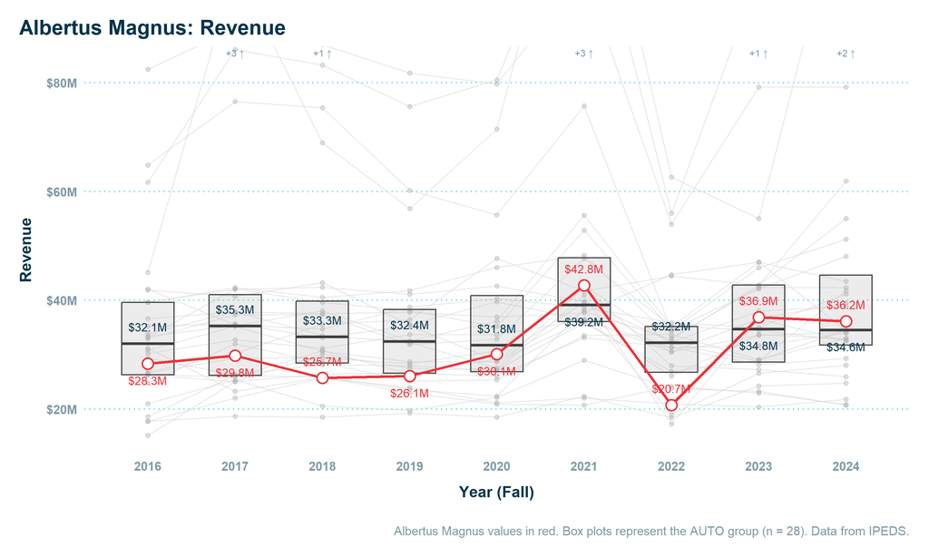

**Expenses**

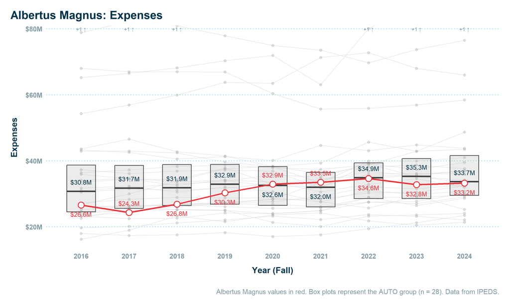

**Margin**

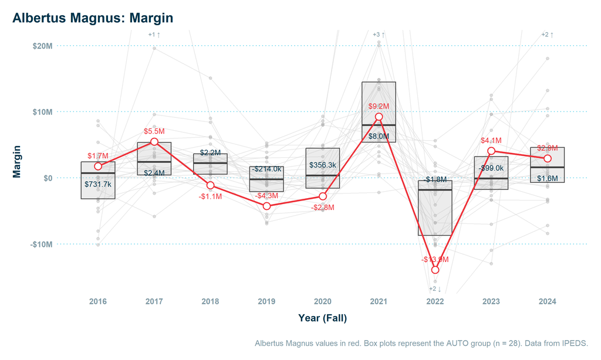

**Endowment**

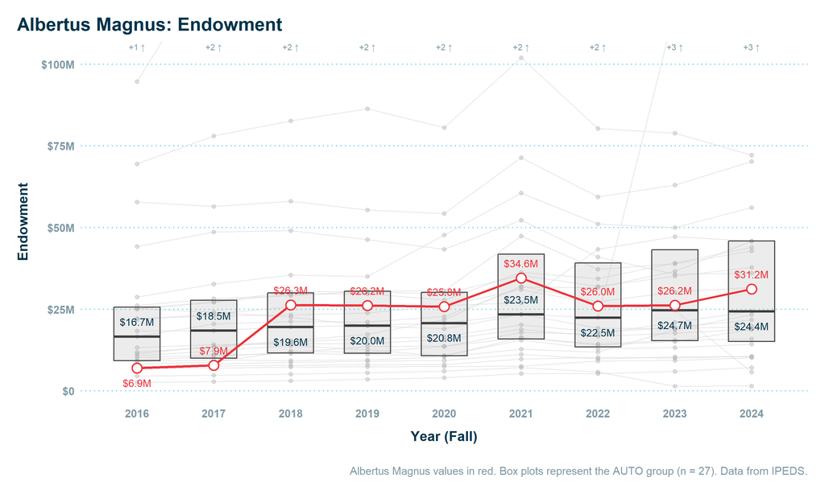

**Avg Net Price**

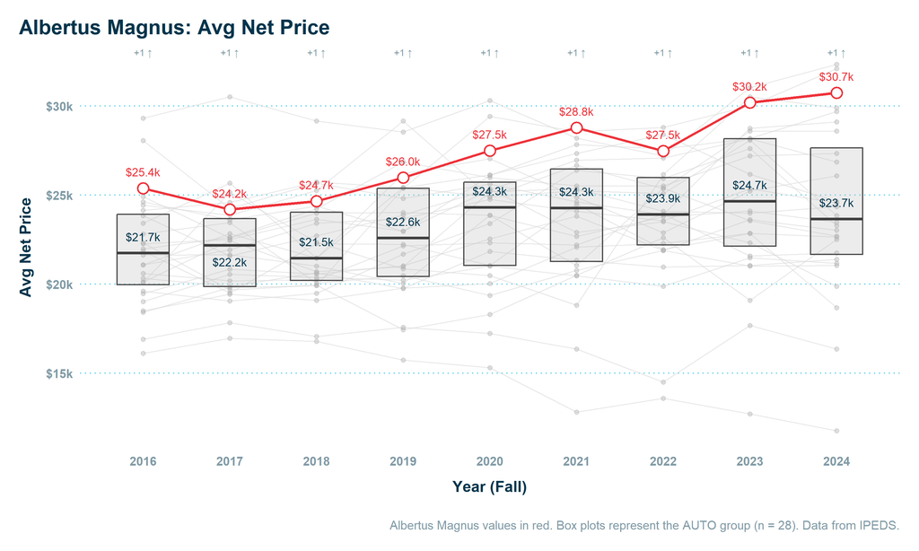

**Avg Net Price + 0.04 * Endowment / UG FTE**

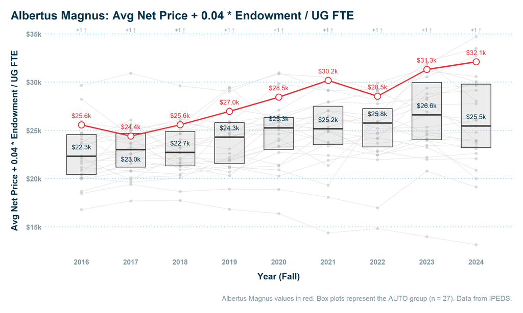

**12-Month Unduplicated Headcount**

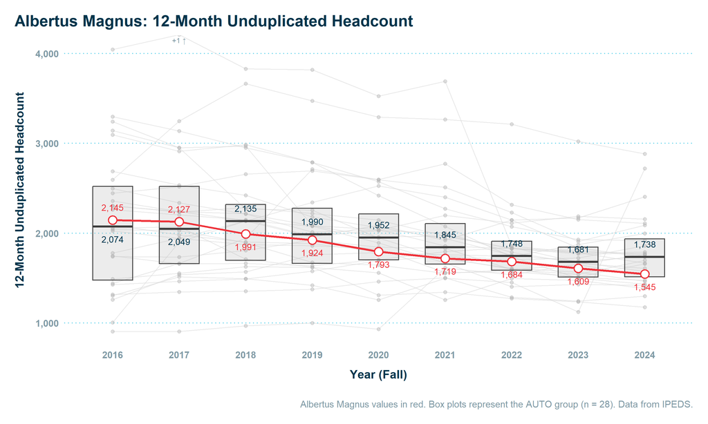

**Undergrad FTE**

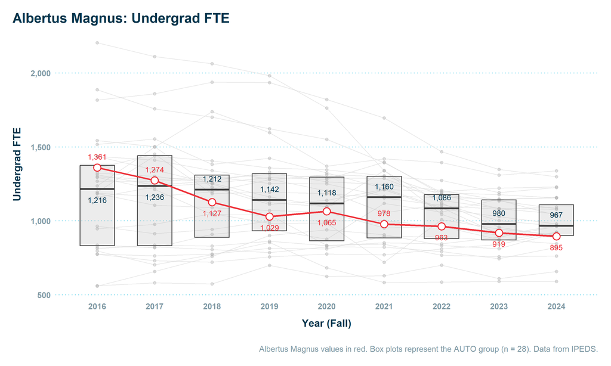

**Grad FTE**

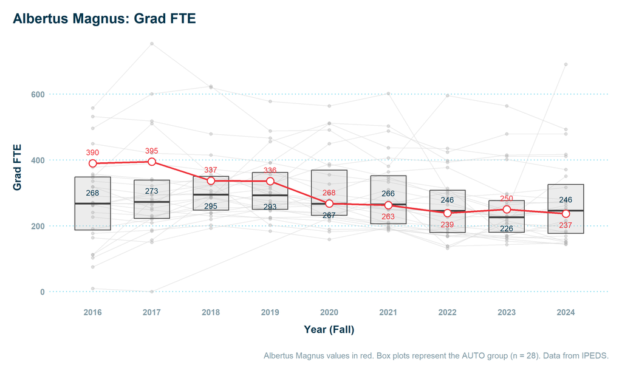

**Doc Prof Prac FTE**

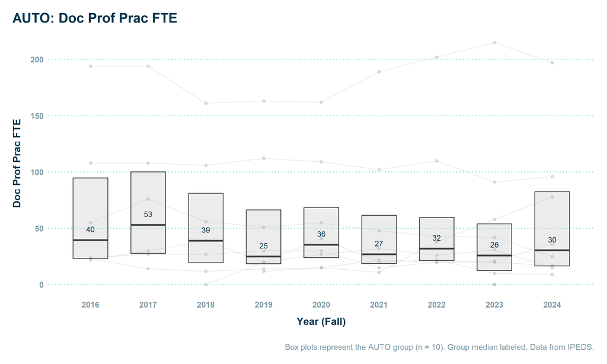

**Total FTE**

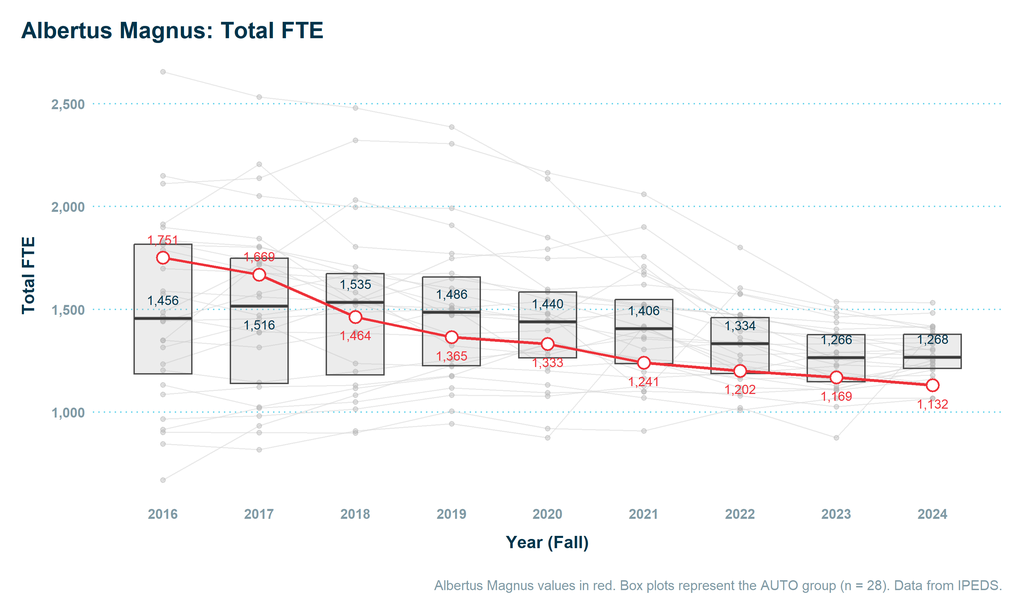

**Student-to-Faculty Ratio**

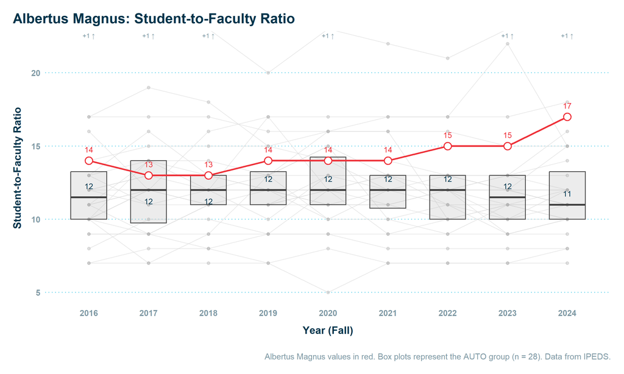

**Undergrad Pell %**

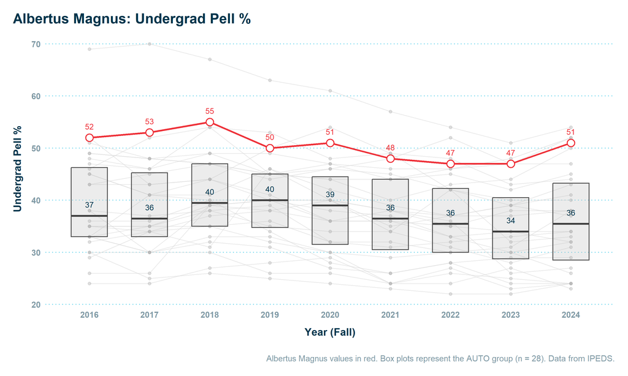

**Program Breadth (distinct 4-digit CIPs)**

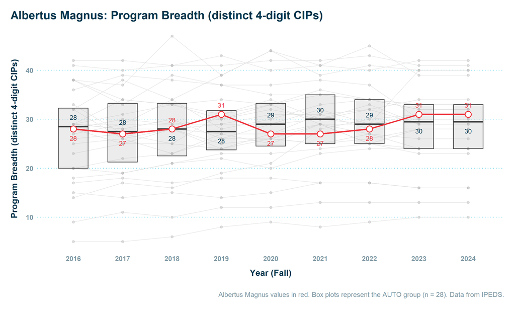

**Top 5 Programs % of Completions**

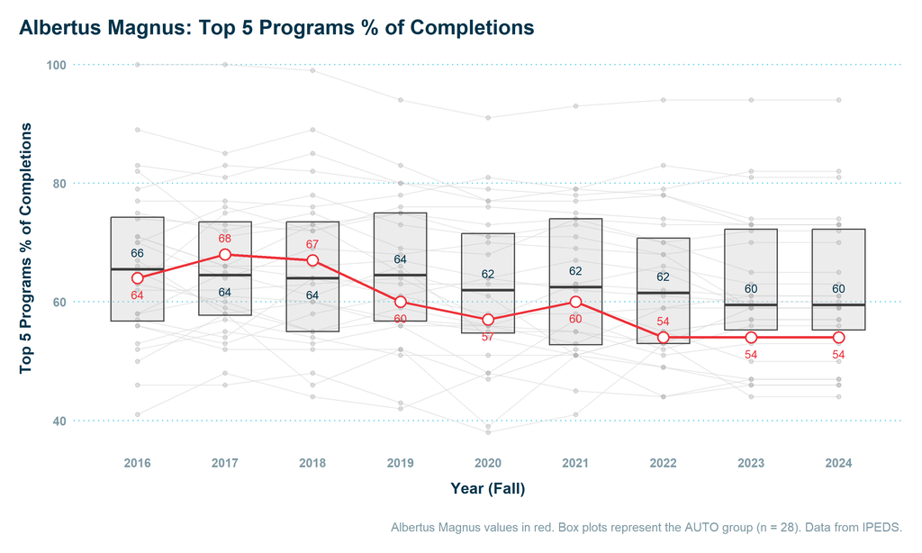

**CUSTOM**

**Revenue**

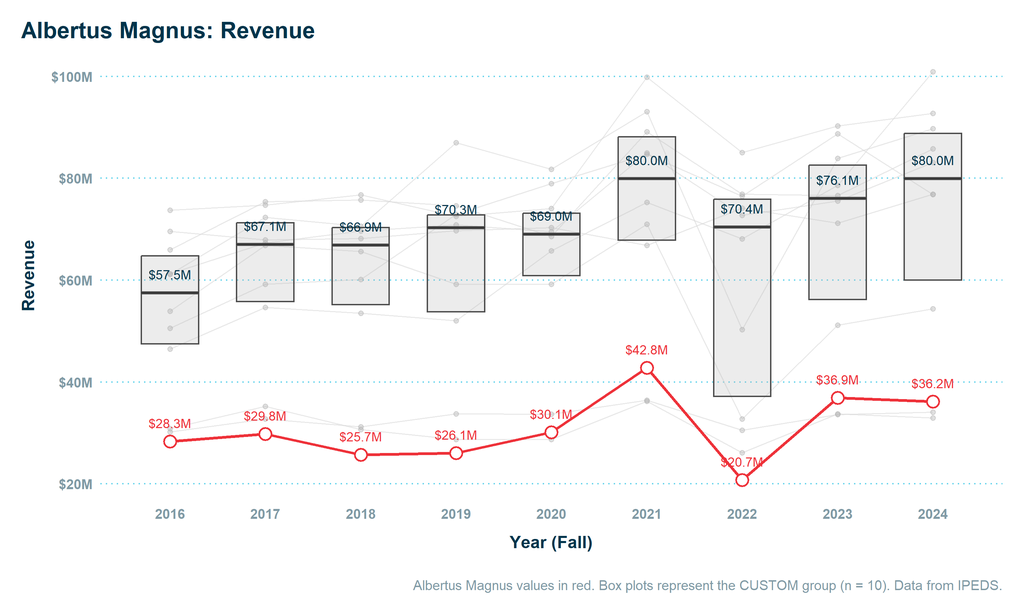

**Expenses**

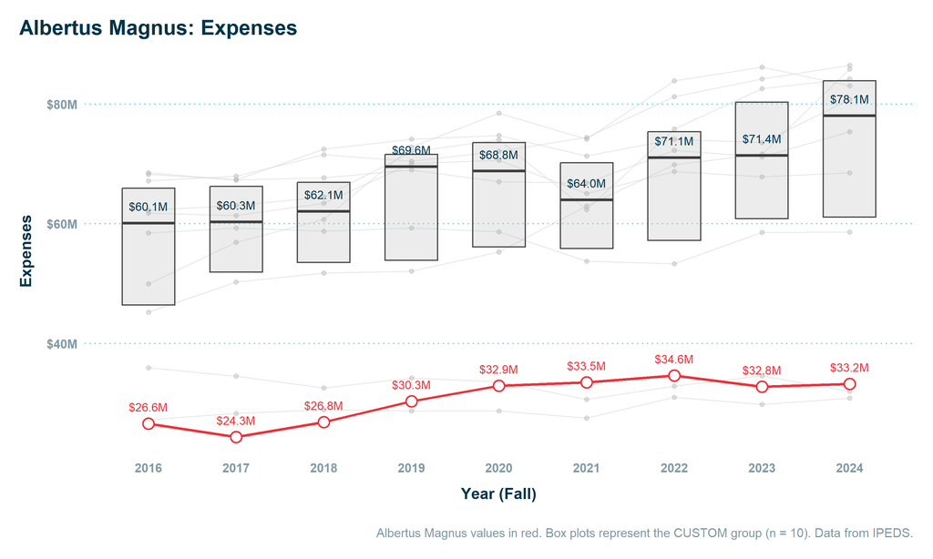

**Margin**

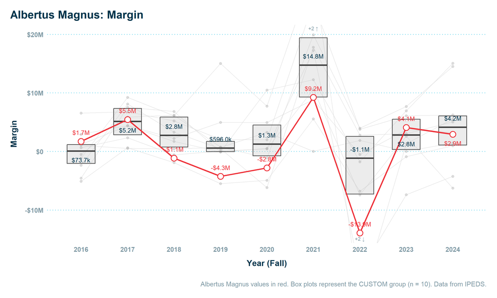

**Endowment**

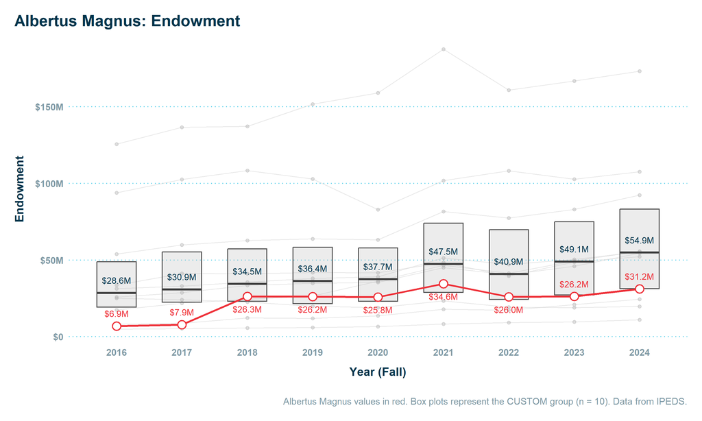

**Avg Net Price**

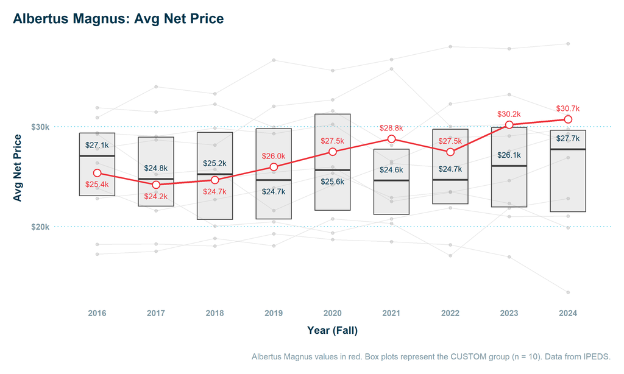

**Avg Net Price + 0.04 * Endowment / UG FTE**

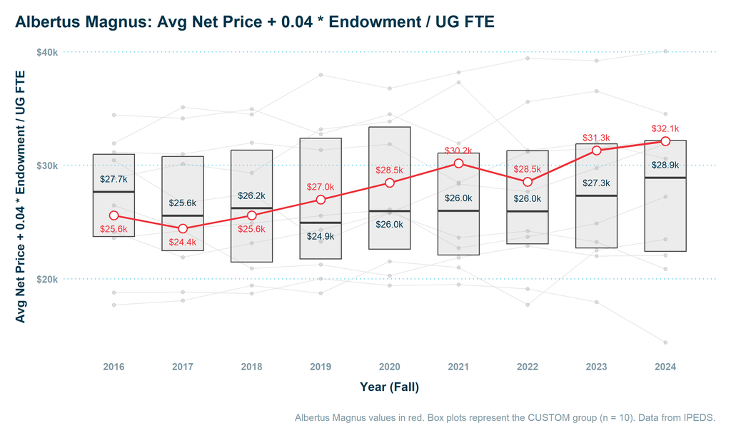

**12-Month Unduplicated Headcount**

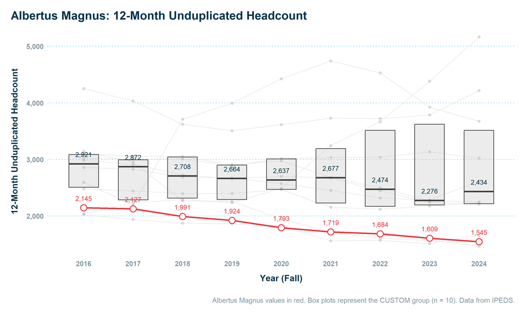

**Undergrad FTE**

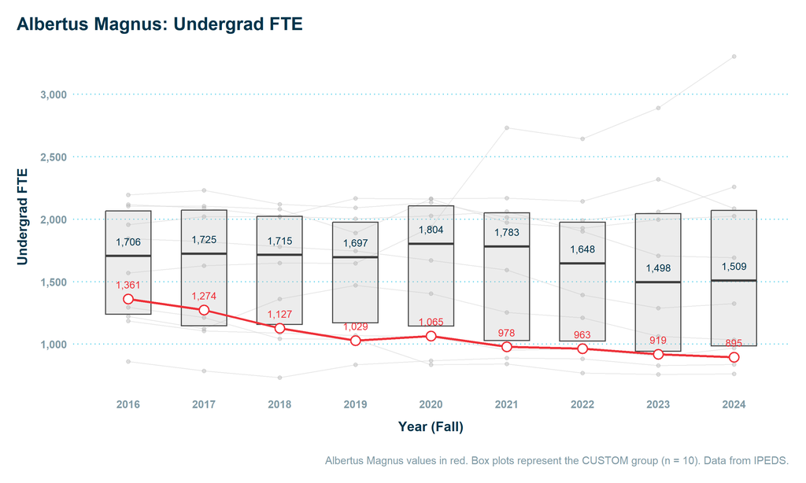

**Grad FTE**

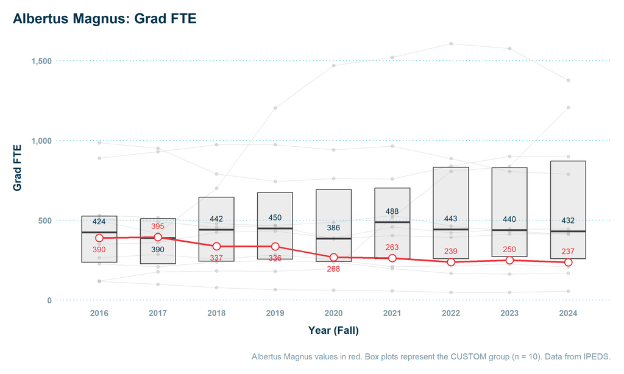

**Doc Prof Prac FTE**

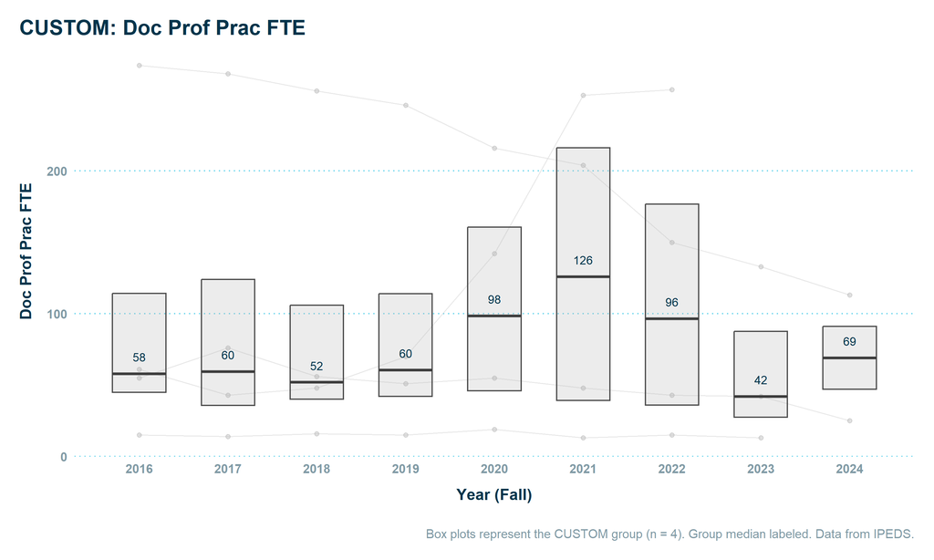

**Total FTE**

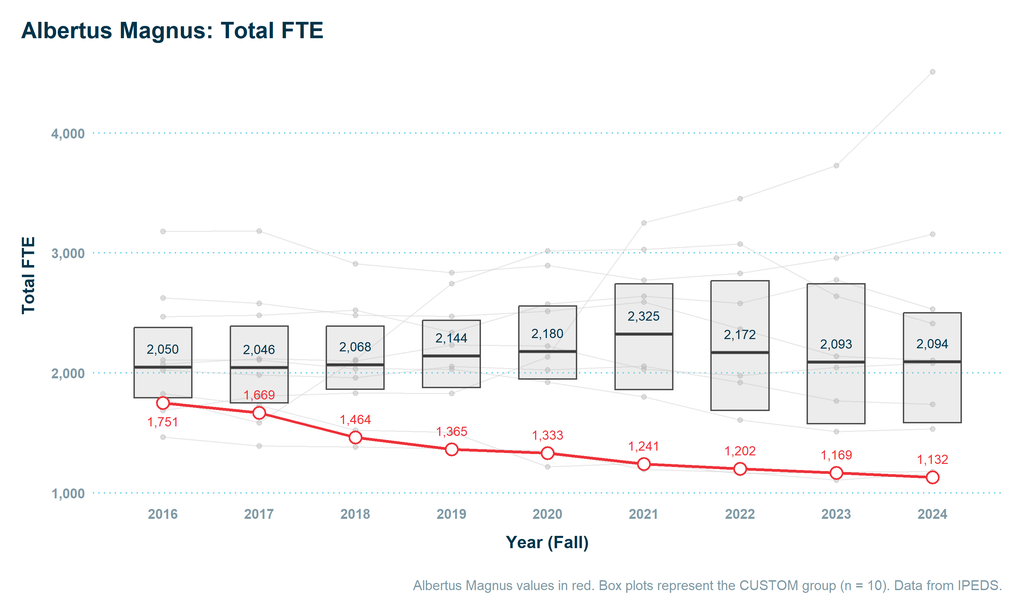

**Student-to-Faculty Ratio**

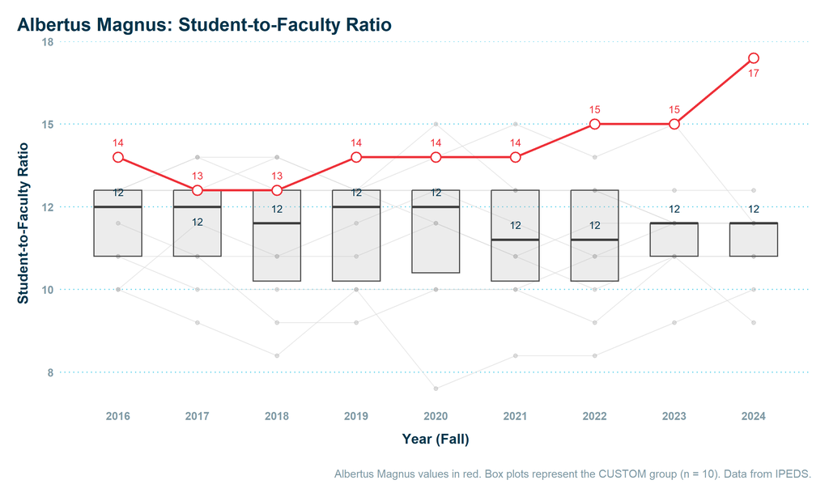

**Undergrad Pell %**

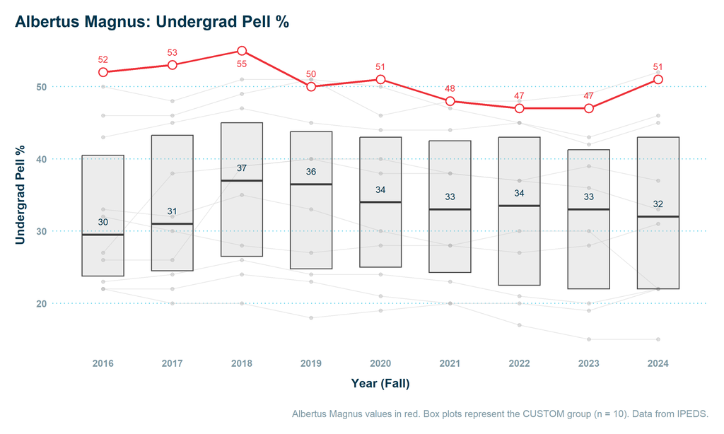

**Program Breadth (distinct 4-digit CIPs)**

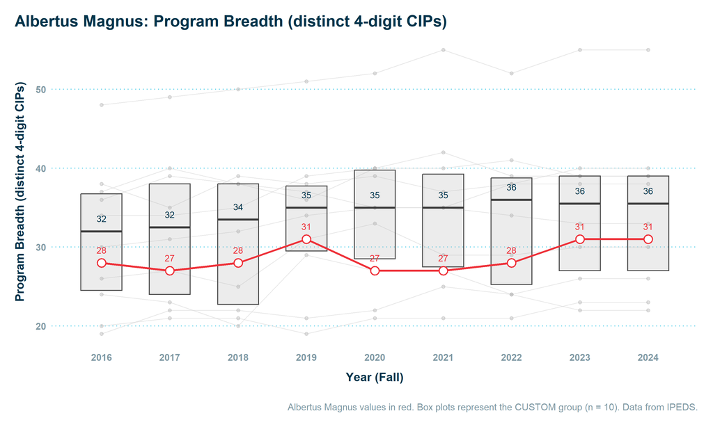

**Top 5 Programs % of Completions**

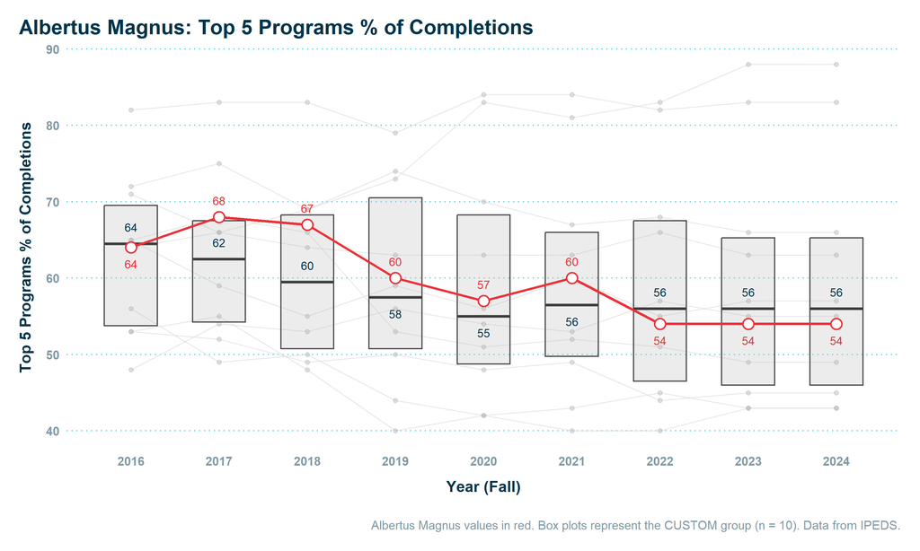

**REVERSE**

**Revenue**